# On interpreting factor relativities

Matthew Van Hala

August 27, 2020

```r
library(dplyr)
library(ggplot2)
library(tidyr)
library(patchwork)
```

```r
print_dt <- function(df, opts = list(), extensions = character(0), scrollX = TRUE, ...) {
  if (scrollX) {
    opts[["scrollX"]] <- TRUE
  }

  DT::datatable(
    df,
    rownames = FALSE,
    extensions = extensions,
    options = opts,
    width = "auto",
    height = "auto",
    ...
  )
}
```

This document addresses pitfalls in thinking about and interpreting factor relativities in an insurance rating algorithm. Some of the pitfalls discussed are elementary, while others may be more subtle.

We also think about ways to move toward an improved method for quantifying the segmentation provided by a variable.

Throughout this document, we consider the example of relativities for a credit score variable, where the credit score may assume any integer value in the range from 200 to 900.

# 1 Basic pitfall: differences in factor values are not invariant to base levels, but ratios are

A naive metric one might think of for describing the segmentation, conceptualized as the “spread”, provided by a factor is the subtraction between the highest and lowest values of the factor.

In a multiplicative rating structure, additive differences are not useful to consider. One should always think in terms of *ratios* between factor values, not additive differences.

Let’s consider three versions of a credit score factor.

```r
tribble(
  ~range, ~v1, ~v2, ~v3,
  "200 - 300", 7, 3.5, 1.75,
  "300 - 400", 6, 3, 1.5,
  "400 - 500", 5, 2.5, 1.25,
  "500 - 600", 4, 2, 1,
  "600 - 700", 3, 1.5, 0.75,
  "700 - 800", 2, 1, 0.5,
  "800 - 900", 1, 0.5, 0.25
) %>%
  print_dt(
    class = "cell-border",
    opts = list(dom = "t"),
    colnames = c("Score range", "Version 1", "Version 2", "Version 3")
  ) %>%
  DT::formatRound(2:4)
```

| Score range | Version 1 | Version 2 | Version 3 |
| --- | --- | --- | --- |
| 200 - 300 | 7 | 3.5 | 1.75 |
| 300 - 400 | 6 | 3 | 1.5 |
| 400 - 500 | 5 | 2.5 | 1.25 |
| 500 - 600 | 4 | 2 | 1 |
| 600 - 700 | 3 | 1.5 | 0.75 |
| 700 - 800 | 2 | 1 | 0.5 |
| 800 - 900 | 1 | 0.5 | 0.25 |

In version 1, the range 800-900 is the base level. In version 2, 700-800 is the base level; and in version 3, 500-600 is the base level.

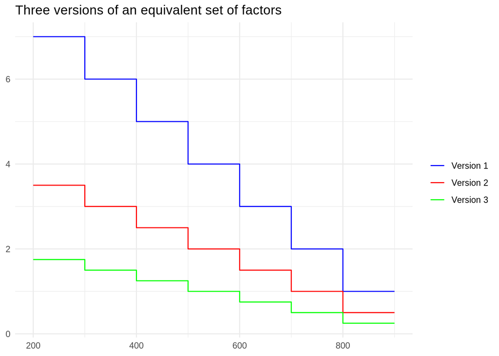

```r
pitfall_base_level <- tibble(
  score = 200:900
) %>%
  mutate(
    `Version 1` = stepfun(seq(300, 800, by = 100), seq(7, 1, by = -1))(score),
    `Version 2` = stepfun(seq(300, 800, by = 100), seq(3.5, 0.5, by = -0.5))(score),
    `Version 3` = stepfun(seq(300, 800, by = 100), seq(1.75, 0.25, by = -0.25))(score)
  ) %>%
  pivot_longer(c(-score), names_to = "version", values_to = "factor")

ggplot(data = pitfall_base_level) +
  theme_minimal() +
  geom_step(aes(x = score, y = factor, color = version)) +
  scale_color_manual(values = pals::glasbey(3)) +
  theme(axis.title = element_blank(), legend.title = element_blank()) +
  ggtitle("Three versions of an equivalent set of factors")
```

With version 3, the base rate is set to two times the base rate for version 2, which is two times the base rate of version 1.

Would it make sense to calculate the “segmentation” of these different factors by taking the difference between the highest and lowest levels? That is, we would get 7 - 1 = 6 for version 1, 3 for version 2, and 1.5 for version 3.

No. These three versions are all equivalent. The three curves are simply scaled versions of each other. Version 2 is one-half times Version 1, and Version 3 is one-fourth times Version 1. The final calculated premiums are identical, as the differences due to factor scales resulting from base level selection get cancelled out in the base rates.

If we rebase all of them to a common base level, we observe that there are identical.

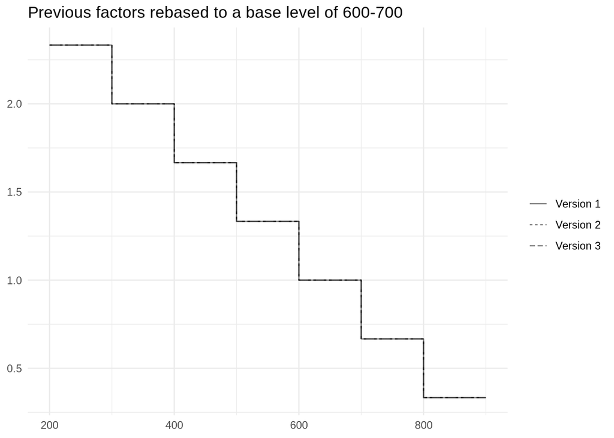

```r
pitfall_base_level_rebased <- pitfall_base_level %>%
  mutate(
    factor_rebased = case_when(
      version == "Version 1" ~ factor / 3,
      version == "Version 2" ~ factor / 1.5,
      version == "Version 3" ~ factor / 0.75
    )
  )

ggplot(data = pitfall_base_level_rebased) +
  theme_minimal() +
  geom_step(aes(x = score, y = factor_rebased, linetype = version), alpha = 0.5) +
  scale_color_manual(values = pals::glasbey(3)) +
  theme(axis.title = element_blank(), legend.title = element_blank()) +
  ggtitle("Previous factors rebased to a base level of 600-700")
```

Notice that if instead of taking the difference between the largest and smallest factors, we took the ratio as our measure of “spread”/“segmentation”, all three version are identical (7 / 1 = 3.5 / 0.5 = 1.75 / 0.25 = 7).

What is the lesson here? Within a multiplicative rating structure, if you are comparing different versions of factors of one variable, if one wants to think about the “spread” of a variable in terms of the range between the highest and lowest values, one must compute the ratio between the highest and lowest values, not the subtraction difference.

Also, the choice of base level does not matter. The ratio between different factor values is not affected by the choice of base level.

## 1.1 Sub-pitfall: differences still not valid to consider after rebasing to a common base level

One might ask whether, if we rebase different versions of factors for a variable to a common base level, could we then compare the segmentation by computing the subtraction differences between the highest and lowest levels.

The answer is still no.

Consider two versions of a variable, Version 2 from above and a new version called Version 4.

```r
tribble(
  ~range, ~v2, ~v4,
  "200 - 300", 3.5, 4,
  "300 - 400", 3, 3.2,
  "400 - 500", 2.5, 2.4,
  "500 - 600", 2, 1.8,
  "600 - 700", 1.5, 1.2,
  "700 - 800", 1, 0.9,
  "800 - 900", 0.5, 0.8
) %>%
  print_dt(
    class = "cell-border",
    opts = list(dom = "t"),
    colnames = c("Score range", "Version 2", "Version 4")
  ) %>%
  DT::formatRound(2:3)
```

| Score range | Version 2 | Version 4 |
| --- | --- | --- |
| 200 - 300 | 3.5 | 4 |
| 300 - 400 | 3 | 3.2 |
| 400 - 500 | 2.5 | 2.4 |
| 500 - 600 | 2 | 1.8 |
| 600 - 700 | 1.5 | 1.2 |
| 700 - 800 | 1 | 0.9 |
| 800 - 900 | 0.5 | 0.8 |

Here is a plot comparing these two versions.

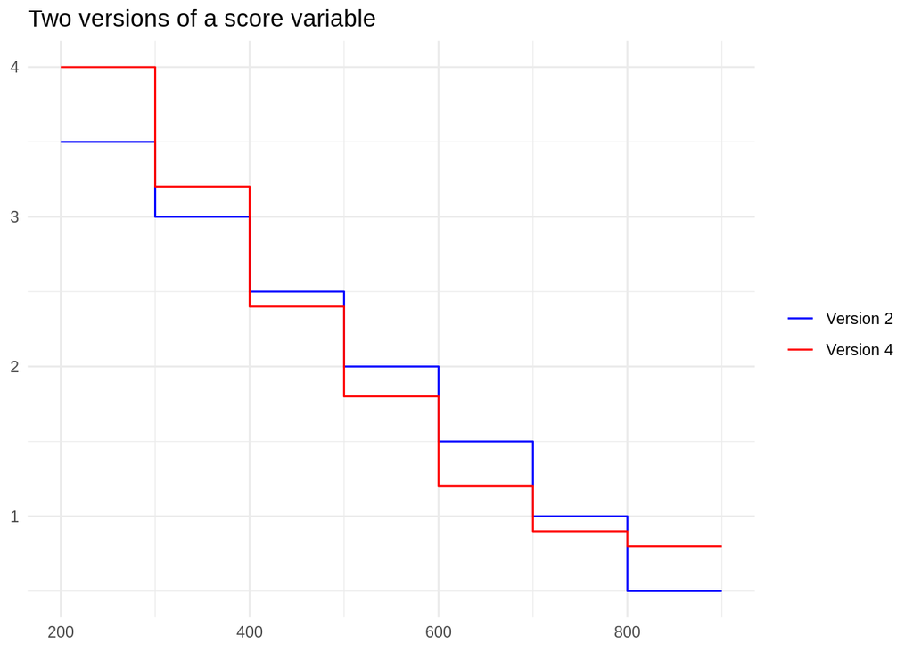

```r
pitfall_base_level <- tibble(
  score = 200:900
) %>%
  mutate(
    `Version 2` = stepfun(seq(300, 800, by = 100), seq(3.5, 0.5, by = -0.5))(score),
    `Version 4` = stepfun(seq(300, 800, by = 100), c(4, 3.2, 2.4, 1.8, 1.2, 0.9, 0.8))(score)
  ) %>%
  pivot_longer(c(-score), names_to = "version", values_to = "factor")

ggplot(data = pitfall_base_level) +
  theme_minimal() +
  geom_step(aes(x = score, y = factor, color = version)) +
  scale_color_manual(values = pals::glasbey(2)) +
  theme(axis.title = element_blank(), legend.title = element_blank()) +
  ggtitle("Two versions of a score variable")
```

The following table shows the versions of these factors under rebasing to two different base levels: 650 and 850.

```r
tribble(
  ~range, ~v2, ~v4,
  "200 - 300", 3.5, 4,
  "300 - 400", 3, 3.2,
  "400 - 500", 2.5, 2.4,
  "500 - 600", 2, 1.8,
  "600 - 700", 1.5, 1.2,
  "700 - 800", 1, 0.9,
  "800 - 900", 0.5, 0.8
) %>%
  mutate(
    v2_rebase_650 = v2 / 1.5,
    v2_rebase_850 = v2 / 0.5,
    v4_rebase_650 = v4 / 1.2,
    v4_rebase_850 = v4 / 0.8
  ) %>%
  print_dt(
    class = "cell-border",
    opts = list(dom = "t"),
    colnames = c(
      "Score range",
      "V2", "V4",
      "V2 (rebased 650)", "V2 (rebased 850)",
      "V4 (rebased 650)", "V4 (rebased 850)"
    )
  ) %>%
  DT::formatRound(2:7)
```

| Score range | V2 | V4 | V2 (rebased 650) | V2 (rebased 850) | V4 (rebased 650) | V4 (rebased 850) |
| --- | --- | --- | --- | --- | --- | --- |
| 200 - 300 | 3.5 | 4 | 2.33333333333333 | 7 | 3.33333333333333 | 5 |
| 300 - 400 | 3 | 3.2 | 2 | 6 | 2.66666666666667 | 4 |
| 400 - 500 | 2.5 | 2.4 | 1.66666666666667 | 5 | 2 | 3 |
| 500 - 600 | 2 | 1.8 | 1.33333333333333 | 4 | 1.5 | 2.25 |
| 600 - 700 | 1.5 | 1.2 | 1 | 3 | 1 | 1.5 |
| 700 - 800 | 1 | 0.9 | 0.666666666666667 | 2 | 0.75 | 1.125 |
| 800 - 900 | 0.5 | 0.8 | 0.333333333333333 | 1 | 0.666666666666667 | 1 |

Under the rebasing to 650, the subtraction difference for Version 2 is 2.33 - 0.33 = 2.00, and for Version 4 it is 3.33 - 0.67 = 2.67

Under the rebasing to 850, the subtraction difference for Version 2 is 7.00 - 1.00 = 6.00, and for Version 4 it is 5.00 - 1.00 = 4.00.

Not only is do the actual values of differences between Versions 2 and 4 change between the 650 and 850 rebasing, but which version has a greater difference also changes! Under 650 rebasing, Version 4 has a greater subtraction difference between high and low values, but under 850 rebasing, Version 2 has a greater subtraction difference.

However, when we look at ratios, the ratio between high and low values remains the same and is unaffected by choice of base level.

For Version 2, the high/low ratio is (3.50 / 0.50 = 2.33 / 0.33 = 7.00 / 1.00 = 7), and for Version 4, the high/low ratio is (4.00 / 0.80 = 3.33 / 0.67 = 5.00 / 1.00 = 5).

To conclude on this basic pitfall, if you want to consider the “spread” of factors for a variable, make sure to use ratios in comparing levels, and also remember that the selected base level is *irrelevant*.

# 2 Pitfalls with the simple spread or number of unique values as measures of segmentation

We’ve seen that in looking at “spread” in a set of factors, one must consider ratios. However, even when applied correctly, there are limitations to this metric as a measure of segmentation.

Another metric we’ve seen applied as a measure of the degree of segmentation is the number of unique values for a factor. This, too, has major limitations.

As we shall see, a significant reason for the limitations is they do not take into account the distribution of the variable in the universe of interest (the overall population or a subset thereof).

## 2.1 Sample credit score distribution

Continuing with our credit score examples, the distribution of credit scores in the population is simulated as:

$$Y \sim 200 + 700 * \textrm{Beta}(\alpha=15,\beta=5)$$

This is, credit score and scaled and shifted from a beta distribution with parameters $\alpha = 15$ and $\beta = 5$. After simulating a draw, we round it to the nearest integer.

and the standard deviation is

$$\sqrt{700^2\frac{(15)(5)}{(15 + 5)^2 (15 + 5 + 1)}} \approx 66.1$$

We’ll simulate a sample of 1 million observations from this distribution.

The following is a histogram of the simulated sample.

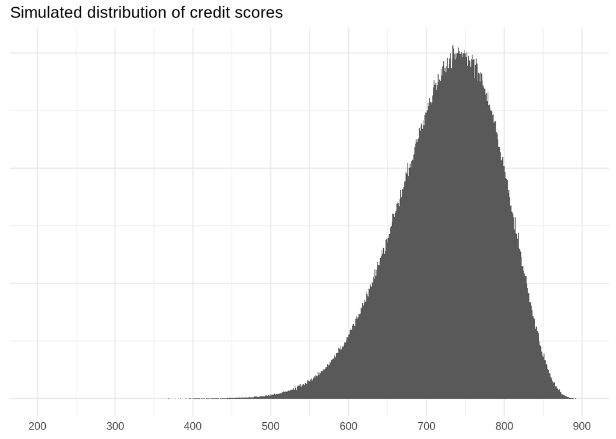

```r
set.seed(400)
score_sample <- tibble(
  score = round(200 + 700 * rbeta(1000000, shape1 = 15, shape = 5))
)

plot_dist <- ggplot(data = score_sample) +
  geom_histogram(aes(x = score), binwidth = 1) +
  theme_minimal() +
  theme(
    axis.title = element_blank(),
    axis.ticks.y = element_blank(),
    axis.text.y = element_blank()
  ) +
  scale_x_continuous(
    breaks = seq(200, 900, by = 100),
    limits = c(200, 900)
  ) +
  ggtitle("Simulated distribution of credit scores")
plot_dist
```

This resembles a credit score distribution we see in internal data, which is left-skewed and where there is very little mass of the distribution on the lower end.

## 2.2 Examples of credit score factor versions

Let’s consider examples of different versions of credit score factors.

Note that we have rebased each version to have a base level of 750. That is, for a score of 750, the factor is 1.0 in each version.

```r
score_versions <- tibble(
  score = 200:900,
  `Version A` = stepfun(c(300, 400, 500, 600), c(8, 6, 4, 2, 1))(score),
  `Version B` = stepfun(c(210, 300, 400, 500, 600, 890), c(10, 8, 6, 4, 2, 1, 0.5))(score),
  `Version C` = approxfun(c(200, 900), c(1.07, 0.93))(score),
  `Version D` = approxfun(c(200, 600, 850, 900), c(8, 1.1, 1, 0.5))(score),
  `Version E` = stepfun(c(200, seq(600, 825, by = 25)), c(2.5, seq(2, 0.6, length.out = 10), 0.5))(score)
)

score_versions_reshaped <- score_versions %>%
  pivot_longer(c(-score), names_to = "version", values_to = "factor") %>%
  left_join(
    filter(., score == 750) %>%
      select(version, factor_base = factor),
    by = c("version")
  ) %>%
  mutate(factor_rebased = factor / factor_base)
```

Here is a plot of all five versions on a single graph.

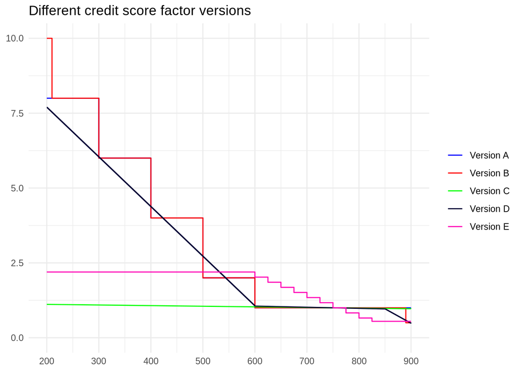

```r
plot_factor <- ggplot(data = score_versions_reshaped) +
  theme_minimal() +
  geom_step(aes(x = score, y = factor_rebased, color = version)) +
  scale_color_manual(values = pals::glasbey(n_distinct(score_versions_reshaped$version))) +
  theme(legend.title = element_blank(), axis.title = element_blank()) +
  ggtitle("Different credit score factor versions") +
  scale_x_continuous(
    breaks = seq(200, 900, by = 100),
    limits = c(200, 900)
  ) +
  scale_y_continuous(limits = c(0, 10))
plot_factor
```

Next we see each on its own separate graph, where the axes are free to vary.

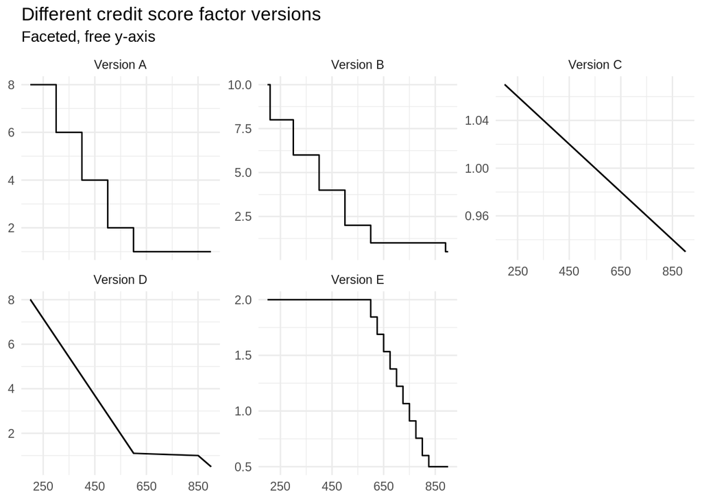

```r
ggplot(data = score_versions_reshaped) +
  theme_minimal() +
  geom_step(aes(x = score, y = factor)) +
  facet_wrap(~version, scales = "free_y") +
  theme(axis.title = element_blank()) +
  ggtitle("Different credit score factor versions", subtitle = "Faceted, free y-axis") +
  scale_x_continuous(
    breaks = c(250, 450, 650, 850),
    limits = c(200, 900)
  )
```

## 2.3 Comparing measures of segmentation

Intuitively, one can readily think of potential drawbacks with spread (high/low ratio) in that it is sensitive to outliers at the extreme of the distribution that may have negligible impact overall. Simply making the values at the high and low points more extreme will increase this measure.

Once can also think of drawbacks with number of distinct values as a metric. One could have a very large number of different values, but each of which are only negligibly different from each other.

For each of the credit score versions, let’s calculate the two metrics mentioned above, namely the spread (high/low relativity ratio) and the number of distinct values.

```r
score_versions %>%
  summarise_at(
    vars(starts_with("Version")),
    list(
      `Spread` = ~max(.) / min(.),
      `# values` = n_distinct
    )
  ) %>%
  pivot_longer(everything(), names_to = "version_metric", values_to = "value") %>%
  separate(version_metric, c("Version", "metric"), sep = "_") %>%
  pivot_wider(names_from = "metric", values_from = "value") %>%
  print_dt(
    class = "cell-border",
    opts = list(dom = "t")
  ) %>%
  DT::formatRound("Spread")
```

| Version | Spread | # values |
| --- | --- | --- |
| Version A | 8 | 5 |
| Version B | 20 | 7 |
| Version C | 1.1505376344086 | 701 |
| Version D | 16 | 701 |
| Version E | 4 | 11 |

Versions B and D have high values on the spread metric, while Versions C and D have large number of distinct factor values. In contrast, Version E has comparatively “mediocre” values for the spread and number of values metrics.

Does this imply Version E is inferior in capturing segmentation compared to the other variables, or that Version D, which has high levels of both spread and distinct values, is superior? No, it does not, as we shall discuss.

First, let’s stack the factor plot on top of the distribution of credit scores.

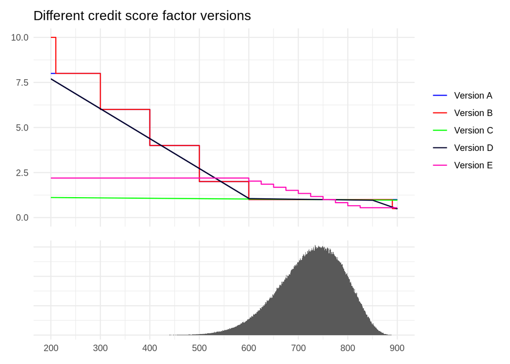

```r
wrap_plots(
  plot_factor +
    theme(
      axis.title.x=element_blank(),
        axis.text.x=element_blank(),
        axis.ticks.x=element_blank()
      ),
  plot_dist +
    theme(plot.title = element_blank()),
  ncol = 1,
  heights = c(2, 1)
)
```

Notice that most of the mass of the distribution of scores is in the 600s and 700s. More than 90% of the distribution is between 600 and 825.

Hardly any of the distribution falls in low credit scores.

If a version jacks up the factors at the lowest credit scores, this can ramp up the spread, but its overall impact on segmentation is negligible.

Compare Version A and Version B. These two are identical, except in the ranges 200-210 (where Version B has a higher factor) and 890-900 (where Version B has a lower factor).

Exaggerating the extremes in this way increases the spread from 8 for Version A to 20 for Version B. However, is there really any more meaningful segmentation provided by Version B? No. A negligible proportion of the population lies in these regions.

Now think about Version C. This scores very highly on number of unique values, as it is a continuous linear interpolation over the entire range of scores. However, the range of values is very narrow.

How about if we think about Version D? This, as a continuous linear interpolation, has a high number of unique values, just like Version C, and it also has a high spread value.

Does this make it ideal for segmentation? No. Let’s compare it to Version E.

Let’s plot factors zoomed in on the scores in the range from 600 to 825, where the bulk of the population is.

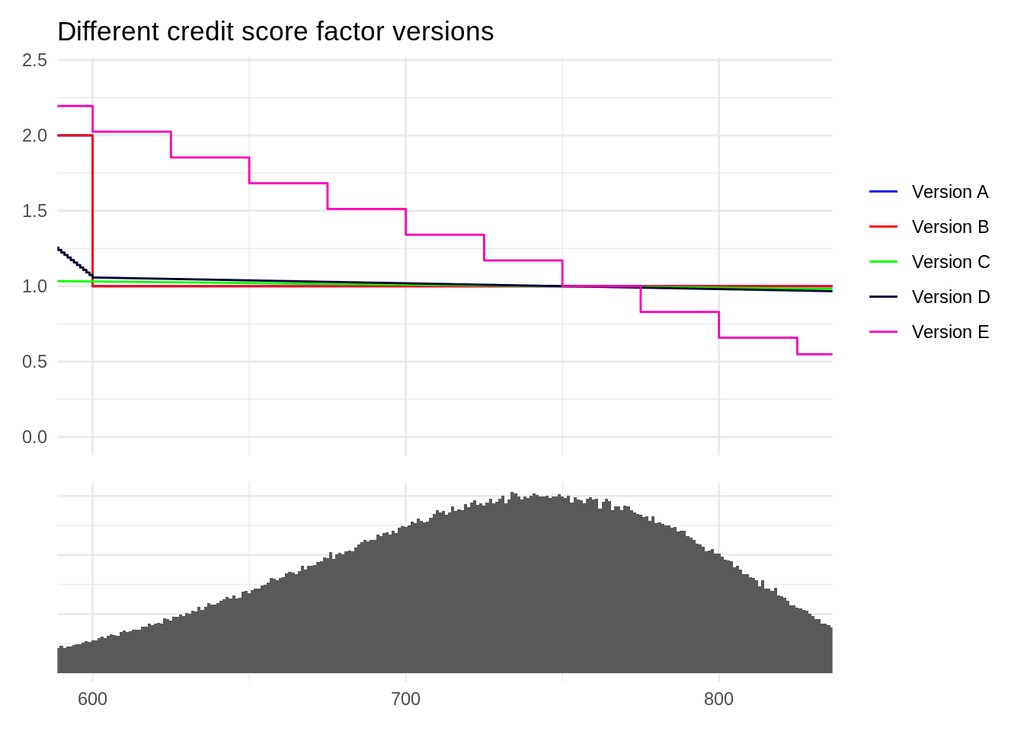

```r
wrap_plots(
  plot_factor +
    theme(
      axis.title.x=element_blank(),
        axis.text.x=element_blank(),
        axis.ticks.x=element_blank()
      ) +
    coord_cartesian(xlim = c(600, 825), ylim = c(0, 2.4)),
  plot_dist +
    theme(plot.title = element_blank()) +
    coord_cartesian(xlim = c(600, 825)),
  ncol = 1,
  heights = c(2, 1)
)
```

By contrast, Version E exhibits the largest degree of variation over this interval, where the bulk of the distribution is.

# 3 A potential better metric for quantifying segmentation

Let’s try to define an improved metric for quantifying the segmentation offered by a set of factors.

Intuitively, we want something that gives more weight to variation where the bulk of the distribution lies. Perhaps we could compute the variance of the factor weighted by the population distribution? We also don’t want the choice of base level to affect our calculated metric. Hence we want to normalize factors.

Thus we’ll define a simulation metric as the variance of the average-rebalanced factor weighted by the population distribution. The average-rebalanced factor is the set of relativities rebalanced such that the average weighted by the population distribution is equal to 1.

One can compute this for a set of observations (such as our simulated sample above) as follows:

1. For each observation, get the corresponding factor relativity factor relativity.
2. Calculate the average relativity over the data set.
3. Divide the relativities by the average.
4. Compute the variance of the rebalance relativity.
5. Higher values mean higher segmentation. Lower values mean lower segmentation.

When we do this for the simulated data set for each of the five versions, we get the following values for this measures.

```r
score_sample %>%
  left_join(score_versions, by = "score") %>%
  summarise_at(vars(-score), ~var(. / mean(.))) %>%
  pivot_longer(everything(), names_to = "Version", values_to = "Segmentation measure") %>%
  print_dt(
    class = "cell-border",
    opts = list(dom = "t")
  ) %>%
  DT::formatRound(2, digits = 4)
```

| Version | Segmentation measure |
| --- | --- |
| Version A | 0.0468765511719087 |
| Version B | 0.0468778096985466 |
| Version C | 0.000187641171883748 |
| Version D | 0.0234715567369213 |
| Version E | 0.118198378777238 |

Consistent with our intuitive discussion in the previous section, Version E has the highest value, implying the highest degree of segmentation by this measure, despite the fact that it had comparatively pedestrian values for high-low spread and number of distinct values.